# AEGIS: single-cell RNA-seq application

This vignette introduces the workflow to simulated single-cell RNA-seq (scRNA-seq) data after retrieving gene sets from the web interface of AEGIS.

## Package Dependencies

The pipeline relies on commonly used packages, so no complicated installation is required.

```python
import os
import json
import numpy as np
import pandas as pd
from scipy import stats, sparse
# for plotting
import matplotlib.pyplot as plt
from matplotlib.colors import LinearSegmentedColormap
```

## Differentially expressed gene sets

### Running the workflow with AEGIS

Prior to this tutorial, we randomly selected 10 genes respectively each from three descendants of the cell cycle process (GO:0022402):

- G1/S transition of mitotic cell cycle (GO:0000082)
- G2/M transition of mitotic cell cycle (GO:0000086)
- mitotic cell cycle arrest (GO:0071850)

The interaction is recorded as part of our Supplementary Videos. For convenience, these genes are copy/pasted here.

```python
gene_sets = {
    "GO:0000082": [ # G1/S transition of mitotic cell cycle
        'CDKN2A',
        'CUL2',
        'ORC5',
        'TFDP3',
        'PHF8',
        'BCAT1',
        'CACUL1',
        'ITGB1',
        'CDC7',
        'USP29',
    ],
    "GO:0000086": [ # G2/M transition of mitotic cell cycle
        'HAUS7',
        'CDKN2B',
        'DCTN1',
        'CEP41',
        'LCMT1',
        'PCM1',
        'FBXW11',
        'HAUS2',
        'CEP57',
        'CEP250',
    ],
    "GO:0071850": [ # mitotic cell cycle arrest
        'E4F1',
        'CDC14B',
        'CDC14A',
        'DUSP1',
        'CDKN1B',
        'MAGI2',
        'CDC14C',
        'GADD45A',
        'NKX3-1',
        'MCPH1',
    ],
}
pop_names = list(gene_sets.keys()) + ["control"]
print("Populations: {}".format(pop_names))
```

```
Populations: ['GO:0000082', 'GO:0000086', 'GO:0071850', 'control']
```

### Retrieving the total set of gene symbols

Next, we specify the non-differentially expressed genes, and check that the selected gene set names are valid. A convient way to get a list of gene names is to used the local file automatically stored for AEGIS. The version-controlled gene name lists are downloadable from: http://stanford.edu/~jjzhu/fileshare/aegis/. You can download a zipped file (e.g., `raw_20180719.tar.gz`), unzip it, and load the file `geneid2sym_*.json` from the path:

```python
CACHE_DIR = "/YOUR/LOCAL/PATH"
```

```python
# load the files from local
SPECIES = "human"
file_name = os.path.join(CACHE_DIR, "geneid2sym_{}.json".format(SPECIES))
with open(file_name) as json_file:
    gene_conversions = json.load(json_file)
all_genes = list(gene_conversions.values())
print("Number of initial genes: {}".format(len(all_genes)))
```

```
Number of initial genes: 20320
```

```python
print(all_genes[:10])
```

```
['A1BG', 'A2M', 'NAT1', 'NAT2', 'SERPINA3', 'AADAC', 'AAMP', 'AANAT', 'AARS', 'ABAT']
```

### Specifying variable genes

As most scRNA-seq pipelines filter out genes with low variability as pre-processing step, we randomly selected 2060 genes (including the signature genes) to be our variable genes. This scale is common for scRNA-seq studies, especially those captured with droplet technologies.

```python
total_gene_list = []
sig_gene_params = {}
for pop in pop_names:
    if pop == "control":
        continue
    total_gene_list += gene_sets[pop] # add signal genes
    for gene in gene_sets[pop]:
        sig_gene_params[gene] = {}

# randomly add other non-differentially expressed genes
np.random.seed(101010)
retain_percentage = 0.1
num_other_genes = int(len(all_genes) * retain_percentage)
all_genes = np.array(all_genes)
sel_idx = np.random.choice(len(all_genes), num_other_genes, replace=False)
other_genes = all_genes[sel_idx]
for sym in other_genes: # add the rest of genes
    if sym not in sig_gene_params:
        total_gene_list.append(sym)
print("Number of variable genes: {}".format(len(total_gene_list)))
print("{} ...".format(total_gene_list[:5]))
```

```
Number of variable genes: 2060
['CDKN2A', 'CUL2', 'ORC5', 'TFDP3', 'PHF8'] ...
```

## Gene expression data modeling

### Randomly select the number of cells in each population

Using the selected gene set, we can create cell sub-populations that are specific to different phases of the cell cycle. In the example, we used 120, 150, 100, 300 cells for G1/S transition, G2/M transition, cell cycle arrest, and control respectively. Each cell type is supposed to have enriched expression of its 10 signature genes; the control cell type is the baseline and does not have enrichment of any of the signature genes.

```python
np.random.seed(111111)
num_cells = {
    "GO:0000082": 120,
    "GO:0000086": 150,
    "GO:0071850": 100,
    "control":    300,
}
tot_num_cells = sum(num_cells.values())
print("Total number of cells:\t{}".format(tot_num_cells))
```

```
Total number of cells:	670
```

### Select the effect size (before dropouts)

To model the counts in the matrix, we choose a zero-inflated negative binomial model similar to [Risso et al. 2018](https://www.nature.com/articles/s41467-017-02554-5).

Under this model, signature and non-signature genes entail different negative binomial parameters. The non-signature follows a negative binomial with parameters $n$, $p$, where $n$ is interpreted as the number of failures and $p$ is the probability of success. To increase the variability among the signature genes, we set gene-specific parameters for $p$ based on a normal distribution. (A low value of $p$ would generally lead to a higher mean expression.)

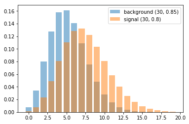

```python
np.random.seed(222222)
n = 30 # general shape parameter
p_null = 0.85
p_sig_m = 0.80
p_sig_s = 0.10

for pop in gene_sets:
    for gene in gene_sets[pop]:
        p = p_sig_s * np.random.normal() + p_sig_m
        sig_gene_params[gene] = {"n": n,
                                 "p": p,
                                 "size":num_cells[pop]}

# plot the two distributions
fig, ax = plt.subplots(1, 1)
x_range = np.arange(0, 20)
for i, p_parm in enumerate([p_null, p_sig_m]):
    z = "background" if i == 0 else "signal"
    ax.bar(x_range,
           stats.nbinom.pmf(x_range, n, p_parm),
           alpha=0.5,
           label="{} ({}, {})".format(z, n, p_parm))
plt.legend()
plt.show()
```

### Adding dropout events to the background of the expression matrix

Here we set the proportion of zero counts, or the dropout probability for the techinical effect. (For efficiency, we work with sparse matrices here.)

```python
background_sparsity = 0.20 # zero fraction: 1-sparsity
np.random.seed(111111)
rvs = stats.nbinom(n=n, p=p_null).rvs
back_mat = sparse.random(tot_num_cells,
                    len(total_gene_list),
                    background_sparsity,
                    data_rvs=rvs)
null_hist = np.histogram(back_mat.A, bins=x_range) # save for plotting later
print("Matrix dimension: {}".format(back_mat.shape))
```

```
Matrix dimension: (670, 2060)
```

### Including the signature gene expression profiles

For efficiency, we generate the expression of the signature genes via a block diagonal matrix and overwrite the background matrix in appropriate positions.

```python
signal_sparsity = 0.50 # zero fraction: 1-sparsity
np.random.seed(222222)
diag_blocks = []
for pop in pop_names:
    n_cells = num_cells[pop]
    print("{}: {} cells".format(pop, n_cells))
    if pop == "control":
        n_null_genes = len(total_gene_list) - len(sig_gene_params)
        sub_mtx = np.zeros((n_cells, n_null_genes))
    else:
        sub_mtx = np.zeros((n_cells, len(gene_sets[pop])))
        for i, gene in enumerate(gene_sets[pop]):
            gene_expr = stats.nbinom.rvs(**sig_gene_params[gene])
            sel = np.random.binomial(1, signal_sparsity, len(gene_expr))
            sub_mtx[:,i] = gene_expr * sel
    print(sub_mtx.shape)
    diag_blocks.append(sub_mtx)
mat = back_mat + sparse.block_diag(diag_blocks)
```

```
GO:0000082: 120 cells
(120, 10)
GO:0000086: 150 cells
(150, 10)
GO:0071850: 100 cells
(100, 10)
control: 300 cells
(300, 2030)
```

### Summarizing the counts after adding drop-outs

```
Number of signal counts: 3700
```

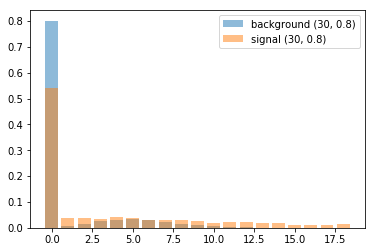

```python
flat_matrices = [m.flatten() for m in diag_blocks[:3]]
signal_counts = np.concatenate(flat_matrices)
print("Number of signal counts: {}".format(len(signal_counts)))
sig_hist = np.histogram(signal_counts, bins=x_range)

fig, ax = plt.subplots(1, 1)
for i, hist_cnt in enumerate([null_hist, sig_hist]):
    z = "background" if i == 0 else "signal"
    norm_freq = hist_cnt[0] / sum(hist_cnt[0])
    ax.bar(hist_cnt[1][:-1],
           norm_freq,
           alpha=0.5,
           label="{} ({}, {})".format(z, n, p_parm))
plt.legend()
plt.show()
```

## Secondary Analysis

The secondary analysis includes three visual components: 1) heatmap view of the expression, 2) projection of the cells in the PC space and 3) the embedding of the cells with t-SNE. These are among the most commonly used techniques for exploratory analysis, even though numerous variants exist.

```python
from sklearn.manifold import TSNE
from sklearn.decomposition import TruncatedSVD
from sklearn.decomposition import PCA
from sklearn.preprocessing import StandardScaler
import seaborn as sns
```

Generate a cell label vector and some meta information for the class labels

```python
label_ids = []
for i, pop in enumerate(pop_names):
    label_ids += [i] * num_cells[pop]
```

```python
col_map = {
    "GO:0000082": "#a6cee3",
    "GO:0000086": "#b2df8a",
    "GO:0071850": "#fb9a99",
    "control": "#EDC500",
}
dark_col_map = {
    "GO:0000082": "#001D71",
    "GO:0000086": "#014B06",
    "GO:0071850": "#630000",
    "control": "#EDC500",
}
text_alias = {
    "GO:0000082": "G1/S \ntransition \nof mitotic \ncell cycle",
    "GO:0000086": "G2/M \ntransition \nof mitotic \ncell cycle",
    "GO:0071850": "mitotic cell \ncycle arrest",
}
```

### Visualize the gene expression matrix

We organize the genes and cell types according to cell types, and include 10 random non-signal genes for the controlled population. Since we front-loaded the signal genes, we just show the top 40 genes in the heatmap. We should expect a block-diagonal structure.

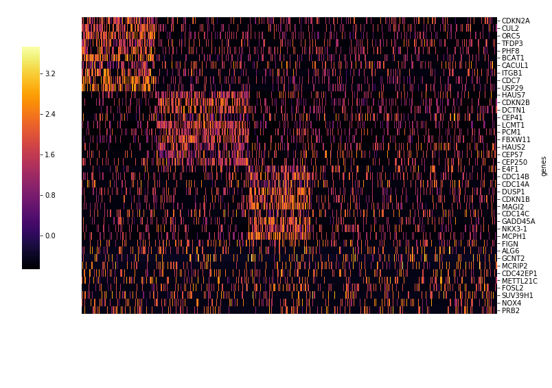

```python
num_genes_to_plot = 40
gene_names = total_gene_list[:num_genes_to_plot]
plot_mtx = StandardScaler().fit_transform(np.log(1+mat.todense()[:, :num_genes_to_plot])).T
plot_mtx = pd.DataFrame(plot_mtx)
plot_mtx["genes"] = gene_names
plot_mtx = plot_mtx.set_index("genes")
g = sns.clustermap(plot_mtx,
               row_cluster=False,
               col_cluster=False,
               cmap="inferno",
               figsize=(12, 10))
g.ax_heatmap.get_xaxis().set_visible(False)
g.ax_heatmap.set_position([.25, 0.26, 0.7, 0.6])
g.cax.set_position([.15, 0.35, 0.03, .45])
```

### Dimension reduction with PCA and t-SNE

PCA is a critical step in dimension reduction. It is also one of the most interpretable unsupervised learning approaches that we can leverage for insightful representation of the data. Note that, before running PCA, we first center the data as a good practice.

```python
np.random.seed(121212)
mat_scaled = StandardScaler(with_std=False).fit_transform(mat.todense())
pc_fit = PCA(n_components=50).fit(mat_scaled)
top_pcs = pc_fit.transform(mat_scaled)
```

To visualize with t-SNE, we use the top 10 PCs. In practice, there are multiple ways to customize t-SNE, but we selected this as it displayed the cell types sufficiently well.

```python
np.random.seed(121212)
tsne_proj = TSNE(n_components=2).fit_transform(top_pcs[:,:10])
print(tsne_proj.shape)
```

[output not shown]

## Plotting the data and annotations

Finally, we can visualize the data and the underlying annotations we designed. For the PCs, we provide biplots that indicate the direction of the signal genes with respect to the PCs. This helps highlight the important ground truth variables.

```python
pc_select = [0,1]
sig_genes = []
sig_group = []
sig_idx = []
offset = 0
max_arr = 10 # the number of arrows to include
for pop in pop_names:
    if pop == "control":
        continue
    for i, gene in enumerate(gene_sets[pop]):
        if i == max_arr:
            break
        sig_genes.append(gene)
        sig_group.append(pop)
        sig_idx.append(offset + i)
    offset += len(gene_sets[pop])
arrow_scaling = np.power( pc_fit.singular_values_[pc_select], 0.4)
v_comp = pc_fit.components_[pc_select,:][:,sig_idx]
arrow_heads = arrow_scaling * v_comp.T # broadcast
arrow_df = pd.DataFrame(arrow_heads, columns=["x", "y"])
arrow_df["ssquare"] = arrow_df["x"]**2 + arrow_df["y"]**2
arrow_df["gene"] = sig_genes
arrow_df["index"] = sig_genes
arrow_df["group"] = sig_group
arrow_df = arrow_df.set_index("index")
pca_proj = top_pcs[:, pc_select] / arrow_scaling
print("Projection dimension: {}".format(pca_proj.shape))
arrow_df.head()
```

```
Projection dimension: (670, 2)
```

| index | x | y | ssquare | gene | group |
| --- | --- | --- | --- | --- | --- |
| CDKN2A | 0.804920 | -0.019913 | 0.648293 | CDKN2A | GO:0000082 |
| CUL2 | 1.311565 | 0.093056 | 1.728863 | CUL2 | GO:0000082 |
| ORC5 | 3.098312 | 0.702640 | 10.093240 | ORC5 | GO:0000082 |
| TFDP3 | 0.736476 | 0.077274 | 0.548369 | TFDP3 | GO:0000082 |
| PHF8 | 1.287511 | 0.129010 | 1.674328 | PHF8 | GO:0000082 |

The t-SNE and PCA plots are customized to for better rendering.

```python
label_size = 15
text_size = 13
tick_label_size = 12

def plot_scatter_groups(projected,
                        label_ids,
                        label_ann,
                        col_map,
                        ax=None,
                        clean=False):
    n_labs = len(label_ann)
    clist = [col_map[lab] for lab in label_ann]
    cmap = LinearSegmentedColormap.from_list("my_list", clist, len(clist))
    scat = ax.scatter(projected[:, 0], projected[:, 1],
                c=label_ids,
                edgecolor="#383838",
                alpha=1.0, s=24.0,
                cmap=cmap)
    dist = (n_labs - 1) / n_labs
    tick_pos = dist * np.arange(n_labs) + dist / 2
    if clean:
        ax.spines['right'].set_visible(False)
        ax.spines['top'].set_visible(False)
    else:
        cb = fig.colorbar(scat, ticks=tick_pos)
        cb.set_ticklabels(label_ann)

def plot_pc_arrows(arrow_df,
                   col_map,
                   ax=None,
                   clean=False):

    grp_max = arrow_df[["ssquare", "gene", "group"]].groupby("group")["ssquare"].transform(max)
    idx = grp_max == arrow_df["ssquare"]
    max_genes = arrow_df[idx].index
    print(max_genes)

    # setup labels
    if not clean:
        ax.set_xlabel("principle component {}".format(pc_select[0]+1),
                      family="arial",
                      size=label_size)
        ax.set_ylabel("principle component {}".format(pc_select[1]+1),
                      family="arial",
                      size=label_size)
    for index, row in arrow_df.iterrows():
        ax.arrow(0, 0, row["x"], row["y"],
                 color=col_map[row["group"]],
                 alpha=0.9,
                 width=0.0001, head_width=0.20)
        x_pos = row["x"]*1.1
        y_pos = row["y"]*1.1
        # manual customization
        if (row["gene"] == 'CDC7'):
            x_pos = row["x"]*1.0
            y_pos = row["y"]*1.4
        if (row["gene"] == "CDKN2B"):
            x_pos = row["x"]*0.9
            y_pos = row["y"]*1.15
        if (row["gene"] == "MCPH1"):
            x_pos = row["x"]*0.9
            y_pos = row["y"]*1.15
        if clean:
            if row["gene"] in max_genes:
                plot_text = True
            else:
                plot_text = False
        else:
            plot_text = True
        if plot_text:
            ax.text(x_pos, y_pos, row["gene"],
                    color=col_map[row["group"]],
                    size = text_size,
                    style="italic",
                    family="arial")
    ax.set_xlim(-3.0, 5.7)
    ax.set_ylim(-3.3, 4.5)
    ax.set_yticks(np.arange(-3, 4, 2.0))
    ax.tick_params(labelsize=tick_label_size)


def plot_tsne_ann(ax, text_alias, col_map, clean=True):
    ax.set_xlim(-50, 55)
    ax.set_ylim(-40, 50)
    ax.tick_params(labelsize=tick_label_size)
    ax.set_yticks(np.arange(-40, 50, 20))
    if not clean:
        ax.set_xlabel("t-SNE dimension 1", family="arial", size=label_size)
        ax.set_ylabel("t-SNE dimension 2", family="arial", size=label_size)

    for term in text_alias:
        x_pos = 0
        y_pos = 0
        if term == "GO:0000082":
            x_pos = 32
            y_pos = -38
        if term == "GO:0000086":
            x_pos = 20
            y_pos = 20
        if term == "GO:0071850":
            x_pos = -47
            y_pos = 20
        ax.text(x_pos, y_pos, text_alias[term],
                size = text_size,
                color=col_map[term], family="arial")
```

```
Index(['CDC7', 'CDKN2B', 'MCPH1'], dtype='object', name='index')
```

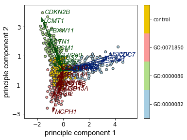

```python
full_figsize = (5.2, 4.3)
fig, ax = plt.subplots(1,1, figsize=full_figsize)
plot_scatter_groups(pca_proj, label_ids, pop_names, col_map, ax=ax)
plot_pc_arrows(arrow_df, dark_col_map, ax=ax)
plt.show()
```

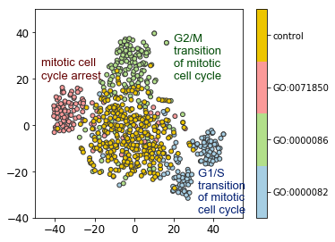

```python
fig, ax = plt.subplots(1,1, figsize=full_figsize)
plot_scatter_groups(tsne_proj, label_ids, pop_names, col_map, ax=ax)
plot_tsne_ann(ax, text_alias, dark_col_map)
plt.show()
```